# Notebook 04 — Multi-State Model (E. coli Levofloxacin)

**2-state continuous-time Markov chain:** Susceptible (S) ↔ notS (Intermediate or Resistant)

**Approach:** Custom MLE via `scipy.linalg.expm` + `scipy.optimize.minimize`

**Sections:**

1. Setup & Load
2. Data Preparation
3. Q Matrix & Likelihood Engine
4. Forward Stepwise Model Selection (candidates: nh_90d, fq_90d, outpatient)
5. AIC Comparison
6. Hazard Ratios
7. Sojourn Profiles
8. State Occupancy Plot
9. Diagnostics — Prevalence plot, KM vs predicted, Obs vs expected transition counts
10. HR Forest Plot

## Section 1 — Setup & Load

```python
import numpy as np
import pandas as pd
import matplotlib.pyplot as plt
import matplotlib.patches as mpatches
from scipy.linalg import expm
from scipy.optimize import minimize
from lifelines import KaplanMeierFitter
import warnings
warnings.filterwarnings("ignore")

OUT_DIR  = "c:/ARMD/Python_Coursework_ARMD_analysis/python_output/"
COV_FILE = "c:/ARMD/output6/03_ecoli_lev_cov_dataset.csv"

cov = pd.read_csv(COV_FILE)
cov["order_time"] = pd.to_datetime(cov["order_time"])

# Fill NA in binary covariates with 0
for col in ["fq_90d", "outpatient", "nh_90d"]:
    cov[col] = cov[col].fillna(0).astype(int)

print(f"Rows: {len(cov):,}  |  Patients: {cov['anon_id'].nunique():,}")
print("\nSusceptibility distribution:")
print(cov["susceptibility"].value_counts())
cov.head(3)
```

```
Rows: 19,374  |  Patients: 6,230

Susceptibility distribution:
susceptibility
Susceptible     16930
Resistant        1942
Intermediate      502
Name: count, dtype: int64
```

|  | order_proc_id_coded | anon_id | order_time | susceptibility | obs_index | n_obs | interval_days | visit_date | era_post2015 | ampi_90d | ampi_days | tmx_90d | tmx_days | fq_90d | fq_days | outpatient | adi_score | adi_tertile | nh_90d |
| --- | --- | --- | --- | --- | --- | --- | --- | --- | --- | --- | --- | --- | --- | --- | --- | --- | --- | --- | --- |
| 0 | 364762539 | JC1000083 | 2010-03-29 21:10:00+00:00 | Susceptible | 1 | 3 | NaN | 2010-03-29 | 0 | 0 | NaN | 0 | NaN | 0 | NaN | 0 | 4.0 | High | 0 |
| 1 | 379081590 | JC1000083 | 2011-02-18 22:25:00+00:00 | Susceptible | 2 | 3 | 326.052083 | 2011-02-18 | 0 | 0 | NaN | 0 | NaN | 0 | NaN | 0 | 4.0 | High | 0 |
| 2 | 384652929 | JC1000083 | 2011-06-18 00:10:00+00:00 | Susceptible | 3 | 3 | 119.072917 | 2011-06-18 | 0 | 0 | NaN | 0 | NaN | 0 | NaN | 0 | 4.0 | High | 0 |

## Section 2 — Data Preparation for MSM

```python
# State encoding: 1 = Susceptible, 2 = notS (I or R)
cov["state"] = np.where(cov["susceptibility"] == "Susceptible", 1, 2)

# Time in years from each patient's first observation
cov["t_yr"] = cov.groupby("anon_id")["order_time"].transform(
    lambda x: (x - x.min()).dt.days / 365.25
)

# Sort
cov = cov.sort_values(["anon_id", "t_yr"]).reset_index(drop=True)

# Remove exact (anon_id, t_yr) duplicates — keep first
cov = cov.drop_duplicates(subset=["anon_id", "t_yr"], keep="first")

# Build consecutive transition pairs
msm = cov.copy()
msm["state_next"] = msm.groupby("anon_id")["state"].shift(-1)
msm["t_next"]     = msm.groupby("anon_id")["t_yr"].shift(-1)
msm["dt"]         = msm["t_next"] - msm["t_yr"]

# Drop last obs per patient and zero-dt rows
msm = msm.dropna(subset=["state_next", "dt"])
msm = msm[msm["dt"] > 0].copy()
msm["state_next"] = msm["state_next"].astype(int)

print(f"Transition pairs: {len(msm):,}")
print("\nObserved transition counts:")
tc = msm.groupby(["state","state_next"]).size().unstack(fill_value=0)
tc.index   = ["S(1)", "notS(2)"]
tc.columns = ["to S(1)", "to notS(2)"]
print(tc)

# Proportions
tc_prop = tc.div(tc.sum(axis=1), axis=0).round(3)
print("\nRow proportions:")
print(tc_prop)

# Save
msm[["anon_id","t_yr","state","state_next","dt",
     "fq_90d","outpatient","nh_90d","adi_score"]].to_csv(
    OUT_DIR + "04_ecoli_lev_msm_data.csv", index=False)
print("\nSaved: 04_ecoli_lev_msm_data.csv")
```

```
Transition pairs: 13,144

Observed transition counts:
         to S(1)  to notS(2)
S(1)       10315        1319
notS(2)      385        1125

Row proportions:
         to S(1)  to notS(2)
S(1)       0.887       0.113
notS(2)    0.255       0.745

Saved: 04_ecoli_lev_msm_data.csv
```

## Section 3 — Q Matrix & Log-Likelihood Engine

For a 2-state CTMC with covariates, the intensity matrix at observation $i$ is: $$Q_i = \begin{pmatrix} -q_{12}^{(i)} & q_{12}^{(i)} \\ q_{21}^{(i)} & -q_{21}^{(i)} \end{pmatrix}$$ where $q_{12}^{(i)} = q_{12} \cdot e^{\boldsymbol{\beta}_{12} \cdot \mathbf{x}_i}$

Transition probabilities: $P(\Delta t) = e^{Q_i \cdot \Delta t}$ (matrix exponential via `scipy.linalg.expm`)

```python
# Initial Q matrix (per year) — from observed empirical transition rates
Q_INIT = np.array([[-0.1618,  0.1618],
                   [ 0.2711, -0.2711]])

print("Initial Q matrix (per year):")
print(pd.DataFrame(Q_INIT, index=["S","notS"], columns=["to S","to notS"]).round(4))
print(f"\nImplied sojourn in S:    {1/0.1618*365.25:.0f} days")
print(f"Implied sojourn in notS: {1/0.2711*365.25:.0f} days")
```

```
Initial Q matrix (per year):
        to S  to notS
S    -0.1618   0.1618
notS  0.2711  -0.2711

Implied sojourn in S:    2257 days
Implied sojourn in notS: 1347 days
```

```python
# Negative log-likelihood (vectorised over observations, loop over expm calls)
# params layout: [log_q12, log_q21,
#                 beta_q12_cov1, beta_q21_cov1,
#                 beta_q12_cov2, beta_q21_cov2, ...]

def neg_log_lik(params, dt_arr, from_arr, to_arr, cov_arrays):
    q12_base = np.exp(params[0])
    q21_base = np.exp(params[1])

    # Accumulate linear predictor per transition type
    lp12 = np.zeros(len(dt_arr))
    lp21 = np.zeros(len(dt_arr))
    for j, x in enumerate(cov_arrays):
        lp12 += params[2 + 2*j]     * x
        lp21 += params[2 + 2*j + 1] * x

    q12_i = q12_base * np.exp(lp12)
    q21_i = q21_base * np.exp(lp21)

    ll = 0.0
    for i in range(len(dt_arr)):
        Q = np.array([[-q12_i[i],  q12_i[i]],
                      [ q21_i[i], -q21_i[i]]])
        P = expm(Q * dt_arr[i])
        p = P[from_arr[i]-1, to_arr[i]-1]
        p = max(float(p), 1e-300)   # numerical floor
        ll += np.log(p)
    return -ll


# Pre-extract numpy arrays (speed)
dt_arr   = msm["dt"].values
from_arr = msm["state"].values.astype(int)
to_arr   = msm["state_next"].values.astype(int)

print(f"Likelihood engine ready — {len(dt_arr):,} transition pairs")

# Quick sanity check on M0 starting point
x0_m0 = np.array([np.log(0.1618), np.log(0.2711)])
ll_init = -neg_log_lik(x0_m0, dt_arr, from_arr, to_arr, [])
print(f"Log-likelihood at Q_INIT: {ll_init:.2f}")
```

[output not shown]

## Section 4 — Forward Stepwise Model Selection

Candidates (from univariable analysis in NB02): `nh_90d`, `fq_90d`, `outpatient`.

**Strategy:**

1. Fit M0 (baseline, no covariates).
2. Step 1 — try each candidate alone; keep the one with the biggest AIC drop (ΔAIC < 0).
3. Step 2 — try adding each remaining candidate to the Step-1 winner; keep the best if it still improves AIC.
4. Step 3 — try adding the last candidate to the Step-2 model; keep if AIC improves.
5. Stop as soon as no further improvement.

**Optimiser strategy:** Nelder-Mead first (robust to expm overflow) → warm L-BFGS-B from NM solution.

```python
def fit_model(cov_names, label=""):
    cov_arrays = [msm[c].values.astype(float) for c in cov_names]
    n_p = 2 + 2 * len(cov_names)
    x0  = np.zeros(n_p)
    x0[0] = np.log(0.1618)
    x0[1] = np.log(0.2711)

    args = (dt_arr, from_arr, to_arr, cov_arrays)

    # Step 1: Nelder-Mead (robust)
    res_nm = minimize(neg_log_lik, x0, args=args, method="Nelder-Mead",
                      options={"maxiter":20000, "xatol":1e-6, "fatol":1e-6})

    # Step 2: warm L-BFGS-B from NM solution
    res_bfgs = minimize(neg_log_lik, res_nm.x, args=args, method="L-BFGS-B",
                        options={"maxiter":2000})

    best = res_bfgs if res_bfgs.fun < res_nm.fun else res_nm
    loglik = -best.fun
    aic    = -2*loglik + 2*n_p

    if label:
        print(f"  {label}: AIC={aic:.2f}  logLik={loglik:.2f}  converged={best.success}  "
              f"q12={np.exp(best.x[0]):.4f}  q21={np.exp(best.x[1]):.4f}")
    return {"label":label, "cov_names":list(cov_names), "params":best.x,
            "logLik":loglik, "AIC":aic, "converged":best.success, "n_param":n_p}


CANDIDATES = ["nh_90d", "fq_90d", "outpatient"]

print("Fitting M0 (baseline)...")
m0 = fit_model([], "M0 baseline")
all_models = [m0]
```

```
Fitting M0 (baseline)...
  M0 baseline: AIC=9972.30  logLik=-4984.15  converged=True  q12=0.2464  q21=0.9532
```

```python
# ── Step 1: each candidate individually ────────────────────────────────────────
print("\n--- Step 1: try each candidate alone ---")
step1 = {}
for cov in CANDIDATES:
    r = fit_model([cov], f"M1_{cov}")
    step1[cov] = r
    print(f"    DELTA-AIC vs M0: {r['AIC'] - m0['AIC']:+.2f}")
    all_models.append(r)

best_s1_name = min(step1, key=lambda c: step1[c]["AIC"])
m1_best = step1[best_s1_name]
print(f"\nStep-1 winner: {best_s1_name}  (AIC={m1_best['AIC']:.2f},  "
      f"dAIC vs M0={m1_best['AIC']-m0['AIC']:+.2f})")

if m1_best["AIC"] >= m0["AIC"]:
    print("No improvement over M0 — stopping at baseline.")
    best_model = m0
else:
    # ── Step 2: add each remaining candidate to step-1 winner ─────────────────
    remaining1 = [c for c in CANDIDATES if c != best_s1_name]
    print(f"\n--- Step 2: add each remaining candidate to {best_s1_name} ---")
    step2 = {}
    for cov in remaining1:
        covs2 = m1_best["cov_names"] + [cov]
        r = fit_model(covs2, f"M2_{best_s1_name}+{cov}")
        step2[cov] = r
        print(f"    DELTA-AIC vs step-1: {r['AIC'] - m1_best['AIC']:+.2f}")
        all_models.append(r)

    best_s2_name = min(step2, key=lambda c: step2[c]["AIC"])
    m2_best = step2[best_s2_name]
    print(f"\nStep-2 winner: +{best_s2_name}  (AIC={m2_best['AIC']:.2f},  "
          f"dAIC vs step-1={m2_best['AIC']-m1_best['AIC']:+.2f})")

    if m2_best["AIC"] >= m1_best["AIC"]:
        print("No improvement at step 2 — stopping at single-variable model.")
        best_model = m1_best
    else:
        # ── Step 3: try the last remaining candidate ───────────────────────────
        remaining2 = [c for c in remaining1 if c != best_s2_name]
        if remaining2:
            last_cov = remaining2[0]
            covs3 = m2_best["cov_names"] + [last_cov]
            print(f"\n--- Step 3: try adding {last_cov} to {m2_best['label']} ---")
            m3_try = fit_model(covs3, f"M3_all3")
            print(f"    DELTA-AIC vs step-2: {m3_try['AIC'] - m2_best['AIC']:+.2f}")
            all_models.append(m3_try)
            if m3_try["AIC"] < m2_best["AIC"]:
                print(f"  -> Improvement — adding {last_cov}.")
                best_model = m3_try
            else:
                print(f"  -> No improvement — stopping at two-variable model.")
                best_model = m2_best
        else:
            best_model = m2_best

print(f"\n==> Final selected model: {best_model['label']}")
print(f"    Covariates: {best_model['cov_names']}")
print(f"    AIC: {best_model['AIC']:.2f}  |  logLik: {best_model['logLik']:.2f}")
```

```
--- Step 1: try each candidate alone ---
  M1_nh_90d: AIC=9975.83  logLik=-4983.92  converged=False  q12=0.2470  q21=0.9564
    DELTA-AIC vs M0: +3.53
  M1_fq_90d: AIC=9934.86  logLik=-4963.43  converged=True  q12=0.2304  q21=0.9663
    DELTA-AIC vs M0: -37.44
  M1_outpatient: AIC=9970.46  logLik=-4981.23  converged=True  q12=0.2620  q21=0.9355
    DELTA-AIC vs M0: -1.85

Step-1 winner: fq_90d  (AIC=9934.86,  dAIC vs M0=-37.44)

--- Step 2: add each remaining candidate to fq_90d ---
  M2_fq_90d+nh_90d: AIC=9938.39  logLik=-4963.20  converged=True  q12=0.2311  q21=0.9704
    DELTA-AIC vs step-1: +3.53
  M2_fq_90d+outpatient: AIC=9931.46  logLik=-4959.73  converged=True  q12=0.2459  q21=0.9431
    DELTA-AIC vs step-1: -3.40

Step-2 winner: +outpatient  (AIC=9931.46,  dAIC vs step-1=-3.40)

--- Step 3: try adding nh_90d to M2_fq_90d+outpatient ---
  M3_all3: AIC=9934.95  logLik=-4959.48  converged=True  q12=0.2477  q21=0.9512
    DELTA-AIC vs step-2: +3.49
  -> No improvement — stopping at two-variable model.

==> Final selected model: M2_fq_90d+outpatient
    Covariates: ['fq_90d', 'outpatient']
    AIC: 9931.46  |  logLik: -4959.73
```

## Section 5 — AIC Comparison

```python
aic_df = pd.DataFrame([{
    "model":     m["label"],
    "covariates": ", ".join(m["cov_names"]) if m["cov_names"] else "(none)",
    "n_param":   m["n_param"],
    "logLik":    round(m["logLik"], 2),
    "AIC":       round(m["AIC"], 3),
    "converged": m["converged"]
} for m in all_models])
aic_df["dAIC"] = (aic_df["AIC"] - aic_df["AIC"].min()).round(3)
aic_df = aic_df.sort_values("AIC").reset_index(drop=True)

print(aic_df.to_string(index=False))
print(f"\nSelected model: {best_model['label']}")

aic_df.to_csv(OUT_DIR + "04_ecoli_lev_aic_table.csv", index=False)
print("Saved: 04_ecoli_lev_aic_table.csv")
```

```
               model                 covariates  n_param   logLik      AIC  converged   dAIC
M2_fq_90d+outpatient         fq_90d, outpatient        6 -4959.73 9931.463       True  0.000
           M1_fq_90d                     fq_90d        4 -4963.43 9934.863       True  3.400
             M3_all3 fq_90d, outpatient, nh_90d        8 -4959.48 9934.952       True  3.489
    M2_fq_90d+nh_90d             fq_90d, nh_90d        6 -4963.20 9938.392       True  6.929
       M1_outpatient                 outpatient        4 -4981.23 9970.456       True 38.993
         M0 baseline                     (none)        2 -4984.15 9972.305       True 40.842
           M1_nh_90d                     nh_90d        4 -4983.92 9975.834      False 44.371

Selected model: M2_fq_90d+outpatient
Saved: 04_ecoli_lev_aic_table.csv
```

## Section 6 — Hazard Ratios from Best Model

HR = exp(β). CIs from numerical Hessian (if positive definite), else reported as NA.

Each covariate has **two betas**: one for S→notS (q12) and one for notS→S (q21).

```python
def extract_hrs(model):
    params    = model["params"]
    cov_names = model["cov_names"]
    n_cov     = len(cov_names)

    # Numerical Hessian for CIs
    from scipy.optimize import approx_fprime
    cov_arrays = [msm[c].values.astype(float) for c in cov_names]
    args = (dt_arr, from_arr, to_arr, cov_arrays)

    eps = 1e-5
    grad_f = lambda p: approx_fprime(p, neg_log_lik, eps, *args)
    try:
        H = np.zeros((len(params), len(params)))
        for i in range(len(params)):
            e = np.zeros(len(params)); e[i] = eps
            H[i] = (grad_f(params + e) - grad_f(params - e)) / (2*eps)
        H = (H + H.T) / 2   # symmetrise
        cov_mat = np.linalg.inv(H)
        se = np.sqrt(np.diag(cov_mat))
        hess_ok = np.all(np.diag(cov_mat) > 0)
    except Exception:
        se = np.full(len(params), np.nan)
        hess_ok = False

    rows = []
    for j, cname in enumerate(cov_names):
        for trans, idx, label in [("S→notS", 2+2*j, "q12"), ("notS→S", 2+2*j+1, "q21")]:
            beta = params[idx]
            hr   = np.exp(beta)
            ci_lo = np.exp(beta - 1.96*se[idx]) if hess_ok else np.nan
            ci_hi = np.exp(beta + 1.96*se[idx]) if hess_ok else np.nan
            rows.append({"covariate":cname, "transition":trans,
                         "beta":round(beta,4), "HR":round(hr,3),
                         "CI_lo":round(ci_lo,3) if not np.isnan(ci_lo) else None,
                         "CI_hi":round(ci_hi,3) if not np.isnan(ci_hi) else None})
    note = "" if hess_ok else "  [Hessian not PD — CIs not available]"
    return pd.DataFrame(rows), note

hr_df, hr_note = extract_hrs(best_model)
print(f"HRs from {best_model['label']}{hr_note}")
print(hr_df.to_string(index=False))

hr_df.to_csv(OUT_DIR + "04_ecoli_lev_hr_table.csv", index=False)
print("\nSaved: 04_ecoli_lev_hr_table.csv")
```

```
HRs from M2_fq_90d+outpatient
 covariate transition    beta    HR  CI_lo  CI_hi
    fq_90d     S→notS  0.4889 1.631  1.294  2.054
    fq_90d     notS→S -0.0325 0.968  0.745  1.257
outpatient     S→notS -0.1166 0.890  0.741  1.069
outpatient     notS→S  0.0548 1.056  0.852  1.309

Saved: 04_ecoli_lev_hr_table.csv
```

## Section 7 — Sojourn Time Profiles

Sojourn in state S = 1/q12, in state notS = 1/q21 (years → × 365.25 for days).

Compare reference (all covariates = 0) vs each covariate exposed (= 1).

```python
def sojourn_profile(model):
    params    = model["params"]
    cov_names = model["cov_names"]
    q12_base  = np.exp(params[0])
    q21_base  = np.exp(params[1])

    rows = [{"profile":"Reference (all=0)",
             "sojourn_S_days":   round(365.25/q12_base, 1),
             "sojourn_notS_days":round(365.25/q21_base, 1)}]

    for j, cname in enumerate(cov_names):
        b12 = params[2 + 2*j]
        b21 = params[2 + 2*j + 1]
        q12_exp = q12_base * np.exp(b12)
        q21_exp = q21_base * np.exp(b21)
        rows.append({"profile": f"{cname}=1 (others=0)",
                     "sojourn_S_days":   round(365.25/q12_exp, 1),
                     "sojourn_notS_days":round(365.25/q21_exp, 1)})
    return pd.DataFrame(rows)

soj_df = sojourn_profile(best_model)
print(f"Sojourn profiles ({best_model['label']}):")
print(soj_df.to_string(index=False))

soj_df.to_csv(OUT_DIR + "04_ecoli_lev_sojourn_profiles.csv", index=False)
print("\nSaved: 04_ecoli_lev_sojourn_profiles.csv")
```

```
Sojourn profiles (M2_fq_90d+outpatient):
                profile  sojourn_S_days  sojourn_notS_days
      Reference (all=0)          1485.3              387.3
    fq_90d=1 (others=0)           910.9              400.1
outpatient=1 (others=0)          1669.0              366.6

Saved: 04_ecoli_lev_sojourn_profiles.csv
```

## Section 8 — State Occupancy Plot

Starting from state S, predict P(in S at time t) and P(in notS at time t) using $P(t) = e^{Q \cdot t}$ for reference vs fq-exposed.

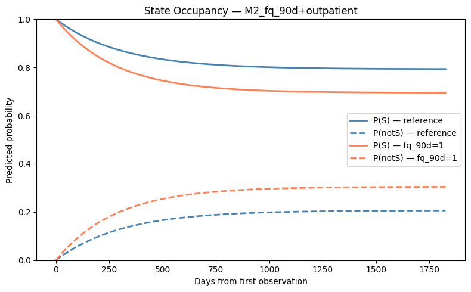

```
Saved: 04_ecoli_lev_state_occupancy.png
```

```python
def state_occupancy(model, cov_vals=None):
    params   = model["params"]
    cov_names = model["cov_names"]
    q12_base = np.exp(params[0])
    q21_base = np.exp(params[1])

    lp12 = lp21 = 0.0
    if cov_vals:
        for j, cname in enumerate(cov_names):
            x = cov_vals.get(cname, 0)
            lp12 += params[2 + 2*j]     * x
            lp21 += params[2 + 2*j + 1] * x

    q12 = q12_base * np.exp(lp12)
    q21 = q21_base * np.exp(lp21)
    Q   = np.array([[-q12, q12], [q21, -q21]])

    t_grid = np.linspace(0, 5, 300)   # 0–5 years
    p0     = np.array([1.0, 0.0])     # start in S
    pS     = np.array([(p0 @ expm(Q * t))[0] for t in t_grid])
    return t_grid * 365.25, pS        # return time in days


t_days_ref, pS_ref = state_occupancy(best_model, cov_vals={c:0 for c in best_model["cov_names"]})

# Pick fq_90d for contrast (if in model)
if "fq_90d" in best_model["cov_names"]:
    fq_vals = {c:0 for c in best_model["cov_names"]}
    fq_vals["fq_90d"] = 1
    t_days_fq, pS_fq = state_occupancy(best_model, cov_vals=fq_vals)
else:
    t_days_fq, pS_fq = None, None

fig, ax = plt.subplots(figsize=(8,5))
ax.plot(t_days_ref, pS_ref,     color="steelblue", lw=2, label="P(S) — reference")
ax.plot(t_days_ref, 1-pS_ref,   color="steelblue", lw=2, ls="--", label="P(notS) — reference")
if pS_fq is not None:
    ax.plot(t_days_fq, pS_fq,   color="coral", lw=2, label="P(S) — fq_90d=1")
    ax.plot(t_days_fq, 1-pS_fq, color="coral", lw=2, ls="--", label="P(notS) — fq_90d=1")

ax.set_xlabel("Days from first observation")
ax.set_ylabel("Predicted probability")
ax.set_title(f"State Occupancy — {best_model['label']}")
ax.legend()
ax.set_ylim(0, 1)
plt.tight_layout()
plt.savefig(OUT_DIR + "04_ecoli_lev_state_occupancy.png", dpi=150)
plt.show()
print("Saved: 04_ecoli_lev_state_occupancy.png")
```

## Section 9 — Model Diagnostics

Three complementary checks:

### 9a. Prevalence Plot

Bin observations by time → compare observed % in state S vs model-predicted. Equivalent to R's `plot.msm()`. Tells you if the model tracks marginal state distribution over time.

### 9b. KM vs Model-Predicted Survival (KM VPC)

For S→notS: the CTMC predicts exponential survival P(still S at t) = exp(−q12·t). Overlay against empirical KM. Divergence = exponential sojourn assumption violated.

### 9c. Observed vs Expected Transition Counts

Bin data by time interval length → compare observed transition counts to model-expected.

```python
# ── 9a: Prevalence Plot ──────────────────────────────────────────────────────

# Bin observations by t_yr into equal-width bins
n_bins = 12
cov["t_bin"] = pd.cut(cov["t_yr"], bins=n_bins)
obs_prev = cov.groupby("t_bin", observed=True)["state"].apply(
    lambda x: (x == 1).mean()
).reset_index()
obs_prev.columns = ["t_bin", "obs_pS"]
obs_prev["t_mid"] = obs_prev["t_bin"].apply(lambda x: x.mid)

# Model-predicted P(S) at each bin midpoint (reference profile)
params   = best_model["params"]
q12_base = np.exp(params[0])
q21_base = np.exp(params[1])
Q_ref    = np.array([[-q12_base, q12_base], [q21_base, -q21_base]])
p0       = np.array([1.0, 0.0])

# Use stationary distribution as starting point (more realistic for prevalence)
# Stationary: pi_S = q21/(q12+q21)
pi_S = q21_base / (q12_base + q21_base)
pi_0 = np.array([pi_S, 1-pi_S])
obs_prev["pred_pS"] = obs_prev["t_mid"].apply(
    lambda t: float((pi_0 @ expm(Q_ref * t))[0])
)

fig, ax = plt.subplots(figsize=(8,4))
ax.plot(obs_prev["t_mid"], obs_prev["obs_pS"],  "o-", color="steelblue", label="Observed % in S")
ax.plot(obs_prev["t_mid"], obs_prev["pred_pS"], "s--", color="coral",    label="Model-predicted % in S")
ax.set_xlabel("Years from first observation")
ax.set_ylabel("Proportion in Susceptible state")
ax.set_title("Diagnostic 9a: Prevalence Plot")
ax.legend()
ax.set_ylim(0, 1)
plt.tight_layout()
plt.savefig(OUT_DIR + "04_ecoli_lev_diag_prevalence.png", dpi=150)
plt.show()
print("Saved: 04_ecoli_lev_diag_prevalence.png")
```

[output not shown]

```python
# ── 9b: KM vs Model-Predicted Survival (KM VPC) ─────────────────────────────
# Focus on S-origin episodes: time until first notS transition

# Build S-origin episodes (same logic as NB03)
cov_sorted = cov.sort_values(["anon_id","order_time"]).copy()
cov_sorted["state_next_km"] = cov_sorted.groupby("anon_id")["state"].shift(-1)
s_origin = cov_sorted[(cov_sorted["state"] == 1) & cov_sorted["state_next_km"].notna()].copy()
s_origin["duration_yr"] = s_origin["t_next"] if "t_next" in s_origin.columns else (
    cov_sorted.groupby("anon_id")["t_yr"].shift(-1) - cov_sorted["t_yr"]
)
# Recompute safely
s_origin["t_yr_next"] = s_origin.groupby("anon_id")["t_yr"].shift(-1)
s_origin = s_origin.dropna(subset=["t_yr_next"])
s_origin["duration_yr"] = s_origin["t_yr_next"] - s_origin["t_yr"]
s_origin["event"] = (s_origin["state_next_km"] == 2).astype(int)
s_origin = s_origin[s_origin["duration_yr"] > 0]

# KM fit
kmf = KaplanMeierFitter()
kmf.fit(s_origin["duration_yr"], event_observed=s_origin["event"], label="KM (observed)")

# Model-predicted: P(still S at t) = exp(-q12 * t) — exponential assumption
t_km = np.linspace(0, s_origin["duration_yr"].max(), 300)
pred_surv = np.exp(-q12_base * t_km)

fig, ax = plt.subplots(figsize=(8,5))
kmf.plot_survival_function(ax=ax, ci_show=True, color="steelblue")
ax.plot(t_km, pred_surv, color="coral", lw=2, ls="--", label="Model-predicted (exp)")
ax.set_xlabel("Years in Susceptible state")
ax.set_ylabel("Probability of remaining in S")
ax.set_title("Diagnostic 9b: KM vs Model-Predicted (S→notS)")
ax.legend()
ax.set_ylim(0, 1)
plt.tight_layout()
plt.savefig(OUT_DIR + "04_ecoli_lev_diag_km_vpc.png", dpi=150)
plt.show()
print("Saved: 04_ecoli_lev_diag_km_vpc.png")
print()
if kmf.median_survival_time_ < np.inf:
    km_med = kmf.median_survival_time_ * 365.25
    model_med = np.log(2) / q12_base * 365.25
    print(f"KM median S sojourn:     {km_med:.0f} days")
    print(f"Model-predicted median:  {model_med:.0f} days")
else:
    model_med = np.log(2) / q12_base * 365.25
    print(f"KM median not reached (>50% still in S)")
    print(f"Model-predicted median: {model_med:.0f} days")
```

[output not shown]

```python
# ── 9c: Observed vs Expected Transition Counts by dt Bin ─────────────────────

# Bin transition pairs by dt (time gap in years)
dt_bins = [0, 0.1, 0.25, 0.5, 1.0, 2.0, np.inf]
dt_labels = ["0-0.1yr","0.1-0.25yr","0.25-0.5yr","0.5-1yr","1-2yr",">2yr"]
msm["dt_bin"] = pd.cut(msm["dt"], bins=dt_bins, labels=dt_labels)

rows = []
for bin_label, grp in msm.groupby("dt_bin", observed=True):
    if len(grp) == 0:
        continue
    dt_mid = grp["dt"].median()
    for fs in [1,2]:
        for ts in [1,2]:
            obs = ((grp["state"]==fs) & (grp["state_next"]==ts)).sum()
            if obs == 0:
                continue
            # Expected: sum of P[fs,ts] for each row
            cov_arrays_m = [grp[c].values.astype(float) for c in best_model["cov_names"]]
            exp_count = 0.0
            for i, (_, row) in enumerate(grp.iterrows()):
                lp12_r = sum(best_model["params"][2+2*j] * row[c]
                             for j,c in enumerate(best_model["cov_names"]))
                lp21_r = sum(best_model["params"][2+2*j+1] * row[c]
                             for j,c in enumerate(best_model["cov_names"]))
                q12_r = q12_base * np.exp(lp12_r)
                q21_r = q21_base * np.exp(lp21_r)
                Qr    = np.array([[-q12_r, q12_r],[q21_r,-q21_r]])
                Pr    = expm(Qr * row["dt"])
                exp_count += Pr[fs-1, ts-1]
            trans_lbl = f"{'S' if fs==1 else 'notS'} -> {'S' if ts==1 else 'notS'}"
            rows.append({"dt_bin":bin_label,"transition":trans_lbl,
                         "observed":obs,"expected":round(exp_count,1),
                         "ratio":round(obs/exp_count,3) if exp_count>0 else None})

obs_exp_df = pd.DataFrame(rows)
print("Observed vs Expected transition counts by dt bin:")
print(obs_exp_df.to_string(index=False))
obs_exp_df.to_csv(OUT_DIR + "04_ecoli_lev_diag_obs_exp.csv", index=False)
print("\nSaved: 04_ecoli_lev_diag_obs_exp.csv")
```

[output not shown]

```python
# ── 9c plot: grouped bar chart ────────────────────────────────────────────────
fig, axes = plt.subplots(1, 4, figsize=(14,4), sharey=False)
trans_labels = ["S -> S","S -> notS","notS -> S","notS -> notS"]

for ax, tlabel in zip(axes, trans_labels):
    sub = obs_exp_df[obs_exp_df["transition"]==tlabel]
    if sub.empty:
        ax.set_title(tlabel); ax.axis("off"); continue
    x = np.arange(len(sub))
    w = 0.35
    ax.bar(x - w/2, sub["observed"], w, color="steelblue", label="Observed")
    ax.bar(x + w/2, sub["expected"], w, color="coral",     label="Expected", alpha=0.8)
    ax.set_xticks(x)
    ax.set_xticklabels(sub["dt_bin"], rotation=30, ha="right", fontsize=7)
    ax.set_title(tlabel, fontsize=9)
    ax.legend(fontsize=7)

fig.suptitle("Diagnostic 9c: Observed vs Expected Transitions by dt Bin", fontsize=11)
plt.tight_layout()
plt.savefig(OUT_DIR + "04_ecoli_lev_diag_obs_exp.png", dpi=150)
plt.show()
print("Saved: 04_ecoli_lev_diag_obs_exp.png")
```

[output not shown]

## Section 10 — HR Forest Plot

Hazard ratios from the best model, for both S→notS and notS→S transitions.

```python
# Split by transition
hr_s_nots = hr_df[hr_df["transition"] == "S→notS"].copy()
hr_nots_s = hr_df[hr_df["transition"] == "notS→S"].copy()

fig, axes = plt.subplots(1, 2, figsize=(11, max(3, len(hr_df)//2 + 1)), sharey=False)

for ax, sub, title, color in [
    (axes[0], hr_s_nots, "S → notS (Resistance acquisition)", "coral"),
    (axes[1], hr_nots_s, "notS → S (Susceptibility recovery)", "steelblue"),
]:
    if sub.empty:
        ax.axis("off"); continue
    y = np.arange(len(sub))
    ax.axvline(1, color="grey", lw=1, ls="--")
    for i, row in sub.reset_index(drop=True).iterrows():
        ax.plot(row["HR"], i, "o", color=color, ms=8, zorder=3)
        if row["CI_lo"] is not None and not pd.isna(row["CI_lo"]):
            ax.plot([row["CI_lo"], row["CI_hi"]], [i, i], color=color, lw=2)
        ax.text(row["HR"], i + 0.15, f'{row["HR"]:.2f}', ha="center", fontsize=8)
    ax.set_yticks(y)
    ax.set_yticklabels(sub["covariate"].values, fontsize=9)
    ax.set_xlabel("Hazard Ratio (log scale)")
    ax.set_xscale("log")
    ax.set_title(title, fontsize=9)
    ax.invert_yaxis()

fig.suptitle(f"HR Forest Plot — {best_model['label']}", fontsize=11)
plt.tight_layout()
plt.savefig(OUT_DIR + "04_ecoli_lev_hr_forest.png", dpi=150)
plt.show()
print("Saved: 04_ecoli_lev_hr_forest.png")
```

[output not shown]

## Summary of Outputs

```python
import os
outputs = [
    "04_ecoli_lev_msm_data.csv",
    "04_ecoli_lev_aic_table.csv",
    "04_ecoli_lev_hr_table.csv",
    "04_ecoli_lev_sojourn_profiles.csv",
    "04_ecoli_lev_state_occupancy.png",
    "04_ecoli_lev_diag_prevalence.png",
    "04_ecoli_lev_diag_km_vpc.png",
    "04_ecoli_lev_diag_obs_exp.csv",
    "04_ecoli_lev_diag_obs_exp.png",
    "04_ecoli_lev_hr_forest.png",
]
print("Output files:")
for f in outputs:
    path = OUT_DIR + f
    exists = os.path.exists(path)
    size   = f"{os.path.getsize(path):,} bytes" if exists else "NOT FOUND"
    print(f"  {'OK' if exists else '!!'} {f}  ({size})")

print(f"\nBest model: {best_model['label']}")
print(aic_df[['model','AIC','dAIC']].to_string(index=False))
```